# IBM Employee Attrition Analysis

**Author:** Payton Lin  
**Date:** 2025/12/02

## 1. Executive Summary

**Project Background:** IBM is currently facing challenges with employee attrition, which negatively impacts business continuity and increases recruitment costs. This project aims to solve this business problem by utilizing data analytics to identify the root causes of turnover.

**Key Results:** * The Random Forest model achieved a prediction accuracy of **87.76%**.

- Key drivers of turnover identified: **Monthly Income**, **Age**, and **Overtime**.

**Key Recommendations:** The HR department is advised to prioritize reviewing the salary structure of key positions and to conduct assessments targeting employees with high overtime workloads.

```python
# 1. 引入必要的分析與繪圖套件
import pandas as pd
import matplotlib.pyplot as plt
import seaborn as sns
import os
from sklearn.ensemble import RandomForestClassifier
from sklearn.metrics import confusion_matrix, accuracy_score
from sklearn.model_selection import train_test_split

# 2. 設定專業的繪圖風格 (讓圖表在網頁上更好看)
plt.style.use('fivethirtyeight')
sns.set_style(style=None)
sns.set_context("notebook", font_scale=1.0)

# 3. 確保圖片輸出資料夾存在 (雖然網頁版不需要，但保留此功能是好習慣)
image_dir = 'report_images'
if not os.path.exists(image_dir):
    os.makedirs(image_dir)

print("✅ 環境設定完成，準備開始分析！")
```

```
✅ 環境設定完成，準備開始分析！
```

## 2. Project Execution: CRISP-DM Process

### Phase 1 & 2: Business & Data Understanding

**Business Objective:** Reduce employee turnover, retain talent, and improve employee satisfaction.

**Data Overview:** The dataset used is the IBM HR Analytics dataset, containing 1470 employee records.

```python
import os
import pandas as pd

print("--- Smart Loading Data ---")

# 1. 設定檔案名稱 & 你的專案資料夾名稱
file_name = 'HR-Employee-Attrition.csv'
project_folder = 'IBM_AnalysisIBM_Analysis'

# 2. 自動導航：不管現在在哪，都試著找到檔案
if os.path.exists(file_name):
    print(f"📍 現在位置正確，直接讀取: {file_name}")
else:
    # 如果找不到，試著往內層資料夾找 (給在大廳的情況用)
    found = False
    for root, dirs, files in os.walk("."):
        if file_name in files:
            print(f"🔍 在子資料夾找到檔案！正在切換路徑至: {root}")
            os.chdir(root)
            found = True
            break

    if not found:
        print(f"❌ 真的找不到檔案。請確認 {file_name} 是否有放在專案資料夾中。")
        print(f"目前 Python 所在的目錄是: {os.getcwd()}")

# 3. 讀取資料
if os.path.exists(file_name):
    df = pd.read_csv(file_name)
    print(f"✅ 成功讀取資料！資料大小: {df.shape}")
    display(df.head())
```

```
--- Smart Loading Data ---
🔍 在子資料夾找到檔案！正在切換路徑至: .\BANA270
✅ 成功讀取資料！資料大小: (1470, 35)
```

|  | Age | Attrition | BusinessTravel | DailyRate | Department | DistanceFromHome | Education | EducationField | EmployeeCount | EmployeeNumber | ... | RelationshipSatisfaction | StandardHours | StockOptionLevel | TotalWorkingYears | TrainingTimesLastYear | WorkLifeBalance | YearsAtCompany | YearsInCurrentRole | YearsSinceLastPromotion | YearsWithCurrManager |
| --- | --- | --- | --- | --- | --- | --- | --- | --- | --- | --- | --- | --- | --- | --- | --- | --- | --- | --- | --- | --- | --- |
| 0 | 41 | Yes | Travel_Rarely | 1102 | Sales | 1 | 2 | Life Sciences | 1 | 1 | ... | 1 | 80 | 0 | 8 | 0 | 1 | 6 | 4 | 0 | 5 |
| 1 | 49 | No | Travel_Frequently | 279 | Research & Development | 8 | 1 | Life Sciences | 1 | 2 | ... | 4 | 80 | 1 | 10 | 3 | 3 | 10 | 7 | 1 | 7 |
| 2 | 37 | Yes | Travel_Rarely | 1373 | Research & Development | 2 | 2 | Other | 1 | 4 | ... | 2 | 80 | 0 | 7 | 3 | 3 | 0 | 0 | 0 | 0 |
| 3 | 33 | No | Travel_Frequently | 1392 | Research & Development | 3 | 4 | Life Sciences | 1 | 5 | ... | 3 | 80 | 0 | 8 | 3 | 3 | 8 | 7 | 3 | 0 |
| 4 | 27 | No | Travel_Rarely | 591 | Research & Development | 2 | 1 | Medical | 1 | 7 | ... | 4 | 80 | 1 | 6 | 3 | 3 | 2 | 2 | 2 | 2 |

5 rows × 35 columns

### Phase 3: Data Preparation

We performed One-Hot Encoding to transform categorical variables into a numeric format suitable for the Random Forest model.

```
--- Data Cleaning & Encoding ---
處理後資料維度: (1470, 45)
```

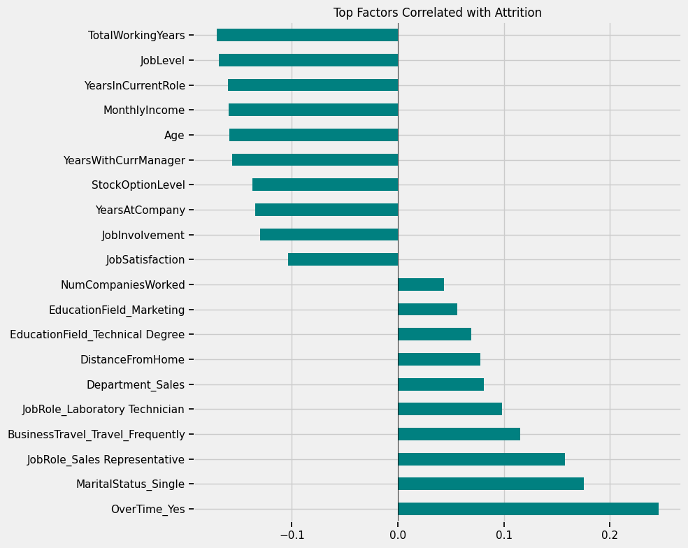

```python
print("--- Data Cleaning & Encoding ---")

# 1. 刪除無用欄位
useless_cols = ['EmployeeCount', 'Over18', 'StandardHours', 'EmployeeNumber']
df_clean = df.drop(columns=[c for c in useless_cols if c in df.columns], axis=1)

# 2. 目標變數編碼 (Yes -> 1, No -> 0)
if 'Attrition' in df_clean.columns:
    df_clean['Attrition'] = df_clean['Attrition'].apply(lambda x: 1 if x == 'Yes' else 0)

# 3. 類別變數 One-Hot Encoding
categorical_cols = df_clean.select_dtypes(include=['object']).columns
df_final = pd.get_dummies(df_clean, columns=categorical_cols, drop_first=True)

print(f"處理後資料維度: {df_final.shape}")

# [視覺化] 影響流失率的前 20 大相關因子
plt.figure(figsize=(10, 8))
correlations = df_final.corr()['Attrition'].sort_values(ascending=False)
top_corr = pd.concat([correlations.drop('Attrition').head(10), correlations.tail(10)])

top_corr.plot(kind='barh', color='teal')
plt.title('Top Factors Correlated with Attrition')
plt.axvline(x=0, color='black', linewidth=0.5)
plt.tight_layout()

# 保存並顯示
plt.savefig(os.path.join(image_dir, '6_correlation_chart.png'), dpi=300, bbox_inches='tight')
plt.show()  # <--- 關鍵！讓圖表顯示在網頁上
```

### Phase 4: Modeling & Evaluation

We used a **Random Forest Classifier** to predict employee attrition.

**Model Performance:**

- **Accuracy:** 87.76%

```
--- Modeling & Evaluation (Random Forest) ---
--------------------------------------------------
🏆 Model Accuracy (模型準確率): 87.76%
--------------------------------------------------
```

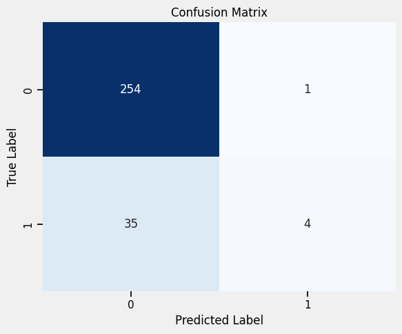

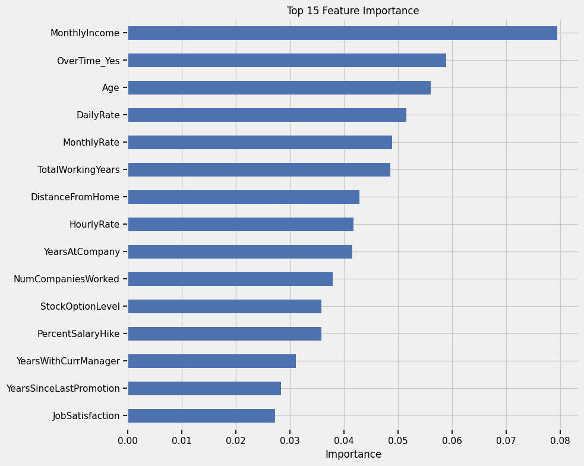

```python
print("--- Modeling & Evaluation (Random Forest) ---")

# 1. 切分訓練集與測試集
X = df_final.drop('Attrition', axis=1)
y = df_final['Attrition']
X_train, X_test, y_train, y_test = train_test_split(X, y, test_size=0.2, random_state=42)

# 2. 訓練模型
rf_model = RandomForestClassifier(n_estimators=100, random_state=42)
rf_model.fit(X_train, y_train)

# 3. 預測結果
y_pred = rf_model.predict(X_test)
accuracy = accuracy_score(y_test, y_pred)

print(f"--------------------------------------------------")
print(f"🏆 Model Accuracy (模型準確率): {accuracy:.2%}")
print(f"--------------------------------------------------")

# [視覺化 1] 混淆矩陣
plt.figure(figsize=(6, 5))
cm = confusion_matrix(y_test, y_pred)
sns.heatmap(cm, annot=True, fmt='d', cmap='Blues', cbar=False)
plt.title('Confusion Matrix')
plt.ylabel('True Label')
plt.xlabel('Predicted Label')
plt.tight_layout()
plt.savefig(os.path.join(image_dir, '7_confusion_matrix.png'), dpi=300, bbox_inches='tight')
plt.show() # 顯示圖表

# [視覺化 2] 特徵重要性 (Top 15)
feature_importances = pd.Series(rf_model.feature_importances_, index=X.columns)
top_15 = feature_importances.nlargest(15).sort_values(ascending=True)

plt.figure(figsize=(10, 8))
top_15.plot(kind='barh', color='#4c72b0')
plt.title('Top 15 Feature Importance')
plt.xlabel('Importance')
plt.tight_layout()
plt.savefig(os.path.join(image_dir, '8_feature_importance.png'), dpi=300, bbox_inches='tight')
plt.show() # 顯示圖表
```

## 3. Conclusions & Recommendations

**What could be improved:**

- **Balancing the Data:** Future work should address the class imbalance between "staying" and "leaving" employees.
- **Focusing on Business Costs:** The model should be tuned to be more sensitive to potential leavers to reduce the cost of missed predictions.